# Histology distribution of putative onocgene annotated fusions

K S Gaonkar for D3B ; Jaclyn Taroni for CCDL

### Background

In 04-project-specific-filtering.Rmd as a last step to remove potential false calls, for example if fusion reading-frame could not be determined by the callers (Fusion_Type=="other") we removed them ; if the fusion is a local-rearrangement according to FusionAnnotator we removed them as potential read-throughs.

### Issue

However in v14 and v15 we have gradually we REMOVED the above filtering from putative oncogene fusions to capture some of the edge cases where a known fusion like

- IGH-MYC had reading-frame other
- CAPZ2-MET is annotated as local-rearrangement.

This removal of filtering lets us gather fusion calls known in oncogenic genes per histologies but also adds a lot of fusions which @jaclyn-taroni, @jharenza and I would like to discuss here.

### QC filtering proposed

Here I plot some barplots to identify fusions found in more than 4 broad_histologies to remove fusions found to be artefactual because of the multiple diverse histologies it's found in across OpenPBTA dataset. (We have decided more than 4 here because we have seen that some known fusions like EWSR1−−FLI1 is seen is 4 different broad_histologies in our current clinical file)

dataPutativeFusion file used as input is

- Filtered fusion calls for general cancer specific genes (oncogenic, transcription factor, kinase, COSMIC and TCGA fusions)
- Plus non-oncogenic fusion which are called by both callers and found in more than 2 samples in each histology (these non-oncogenic fusions are removed if they fuse to more than 5 partner fusions or found in more than 1 histology.)

This notebook assumes you are in OpenPBTA-analysis project folder structure and have run steps 1:4 of fusion_filtering

### Load data

```r
#rootdir
root_dir <- rprojroot::find_root(rprojroot::has_dir(".git"))

####load required packages
suppressPackageStartupMessages(library("readr"))
suppressPackageStartupMessages(library("tidyverse"))
suppressPackageStartupMessages(library("reshape2"))
suppressPackageStartupMessages(library("qdapRegex"))

####read putative oncogene fusion files
fusion_calls<-read_tsv(file.path(root_dir,params$dataPutativeFusion))
####read files from results folder
outputfolder<-params$outputfolder

#### get histology file
if ( params$base_run ==0 ){
clinical<-read_tsv(file.path(root_dir, params$histology), guess_max = 10000) %>%
  dplyr::select(Kids_First_Biospecimen_ID, Kids_First_Participant_ID, broad_histology)
} else {
clinical<-read_tsv(file.path(root_dir, params$base_histology), guess_max = 10000) %>%
  dplyr::select(Kids_First_Biospecimen_ID, Kids_First_Participant_ID, broad_histology)
}
# add broad_histology to fusion
fusion_calls<-fusion_calls %>%
  left_join(clinical,by=c("Sample"="Kids_First_Biospecimen_ID","Kids_First_Participant_ID"))

#### get count cutoff for histology
countHistology<-params$countHistology
```

##### We want to review subset of filtering options for putative-driver-fusions

- Fusion with "other" fusion_type
- Fusion with LOCAL_REARRANGEMENT|LOCAL_INVERSION in annotation
- All putative-oncogene-fusions

```r
#filter other fusion genes
putative_driver_annotated_other_fusions <- fusion_calls %>%
  dplyr::filter(Fusion_Type=="other") %>%
  unique()



#local rearrangements
putative_driver_annotated_fusions_local<-fusion_calls %>%
  # local rearrangement/adjacent genes
  dplyr::filter(grepl("LOCAL_REARRANGEMENT|LOCAL_INVERSION",annots)) %>%
  unique()
```

```r
# function to plot fusion found in N histology
# @param standardFusionCalls: standardized fusion calls
# @param filterN: filter to plot fusions found in more than filterN histologies
# @param plot_title: for plot title per subset of fusion

plotNhist<-function(standardFusionCalls,filterN,plot_title){
  # get count of number of broad_histology per FusionName
  plotNhist<-standardFusionCalls %>% dplyr::select(FusionName,broad_histology) %>% unique() %>%
    group_by(FusionName) %>% tally(name="count")
  # get count of number of times fusion is found in dataset
  # this number helps with identifying how many calls will be reduced from final fusion set
  plotNhist_total_count<-standardFusionCalls %>% dplyr::select(FusionName) %>% group_by(FusionName) %>%
    tally(name="totalcount")

  # get x and y variables for plotNhist plot
  plotNhist<-plotNhist %>% left_join(plotNhist_total_count,by=c("FusionName"))
  plotNhist$FusionNameTotal<-paste0(plotNhist$FusionName,"(",plotNhist$totalcount,")")
  #order FusionNames according to count
  plotNhist<-plotNhist[order(plotNhist$count,decreasing = TRUE),]
  if (!is_empty(filterN)){
    plotNhist<-plotNhist[plotNhist$count>filterN,]
  }
  # factor the FusionNames
  plotNhist$FusionNameTotal<-factor(plotNhist$FusionNameTotal,levels=unique(plotNhist$FusionNameTotal),ordered = TRUE)
  # plot
  ggplot(plotNhist)+geom_col(aes(x=plotNhist$FusionNameTotal,y=plotNhist$count))+theme(axis.text.x = element_text(angle=90))+coord_flip()+ylab("count")+xlab("FusionName(Total)")+ggtitle(plot_title)
}
```

### plot "other" reading-frame fusion found in more than N (countHistology) histologies which might indicate false calls

x axis is number of histologies y axis is the fusion name (total number of calls in putative oncogene list)

```r
# total putative oncogene other fusion
nrow(putative_driver_annotated_other_fusions)
```

```
[1] 1760
```

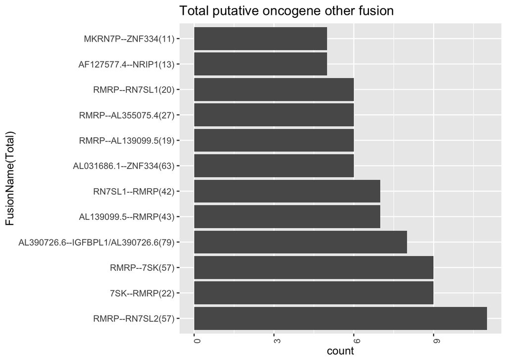

```r
plotNhist(putative_driver_annotated_other_fusions,filterN = countHistology,plot_title ="Total putative oncogene other fusion" )
```

### plot fusion annotated as local rearrangements found in more than N (countHistology) histologies which might indicate false calls

x axis is number of histologies y axis is the fusion name (total number of calls in putative oncogene list)

```r
# total putative oncogene local rearrangement fusion
nrow(putative_driver_annotated_fusions_local)
```

```
[1] 420
```

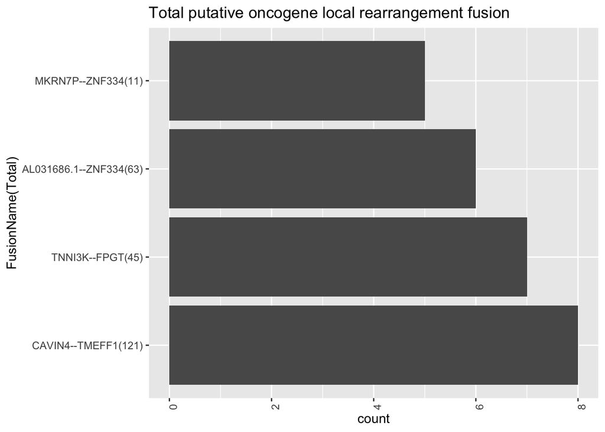

```r
plotNhist(putative_driver_annotated_fusions_local,filterN = countHistology,plot_title ="Total putative oncogene local rearrangement fusion" )
```

### plot all putative oncogene fusion found in more than N (countHistology) histologies which might indicate false calls

x axis is number of histologies y axis is the fusion name (total number of calls in putative oncogene list)

```r
# total putative oncogene fusion
nrow(fusion_calls)
```

```
[1] 7160
```

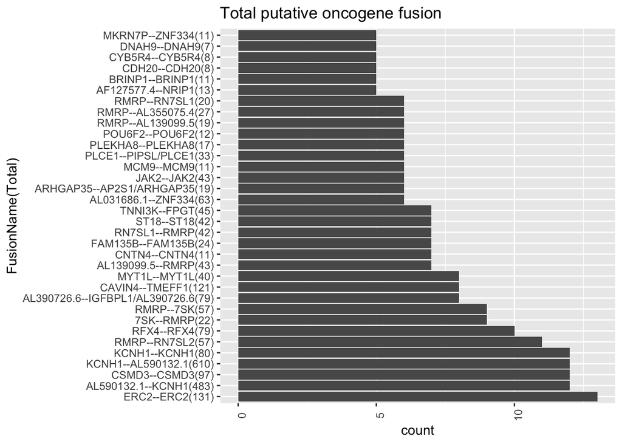

```r
plotNhist(fusion_calls, filterN = countHistology,plot_title = "Total putative oncogene fusion")
```

### get fusions that are found in more than 4 histologies

```r
# count number of fusions in putative oncogene annotated fused gene are in more than N (countHistology) histologies
FusionInNhist<-fusion_calls %>% dplyr::select(FusionName,broad_histology) %>% unique() %>% group_by(FusionName) %>% tally(name="count")
FusionInNhist<-FusionInNhist[FusionInNhist$count>countHistology,]
FusionInNhist
```

| FusionName | count |
| --- | --- |
| 7SK--RMRP | 9 |
| AF127577.4--NRIP1 | 5 |
| AL031686.1--ZNF334 | 6 |
| AL139099.5--RMRP | 7 |
| AL390726.6--IGFBPL1/AL390726.6 | 8 |
| AL590132.1--KCNH1 | 12 |
| ARHGAP35--AP2S1/ARHGAP35 | 6 |
| BRINP1--BRINP1 | 5 |
| CAVIN4--TMEFF1 | 8 |
| CDH20--CDH20 | 5 |

[output cut: 24 more lines]

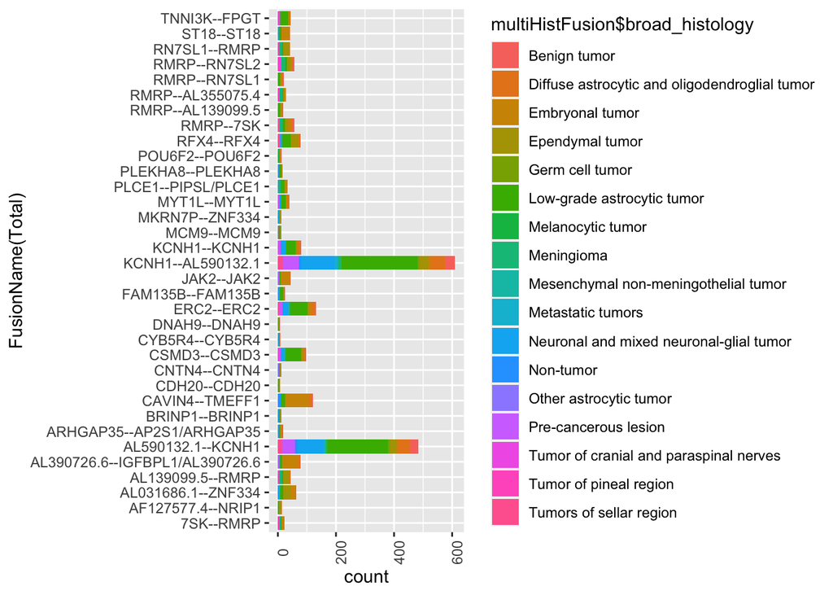

```r
# plot broad_histologies that have Fusions that are potential false positives and found in multiple histologies
multiHistFusion<-fusion_calls %>% dplyr::filter(FusionName %in% FusionInNhist$FusionName) %>%
  # we want to remove annots column since there is difference in arriba annotation (uniquely has duplication/translocation/deletion values) and StarFusion annotation which will be counted twice since they are not unique
  dplyr::select(-annots) %>%
  unique()

ggplot(multiHistFusion,aes(x=multiHistFusion$FusionName,fill=multiHistFusion$broad_histology))+geom_bar()+theme(axis.text.x = element_text(angle=90))+coord_flip()+ylab("count")+xlab("FusionName(Total)")
```

We can assume these fusions to be potential false calls because it is highly unlikely that fusions of biological importance occur in these highly divese histologies. We (Krutika, Jo Lynne and Payal ) also manually reviewed "Total putative oncogene fusion" plots to look for genes that are found in more than 4 histologies and none seemed to interesting/relevant.

```r
putative_driver_fusions<-fusion_calls %>% dplyr::filter(!FusionName %in% FusionInNhist$FusionName) %>%
  # we want to remove annots column since there is difference in arriba annotation (uniquely has duplication/translocation/deletion values) and StarFusion annotation which will be counted twice since they are not unique
  dplyr::select(-annots,-broad_histology) %>%
  unique()

write.table(putative_driver_fusions,file.path(outputfolder,"pbta-fusion-putative-oncogenic.tsv"),sep="\t",quote=FALSE,row.names = FALSE)
```